# Evolution of Sea Ice Extent

Authors: Morales Guerrero, M.J., Gómez Ruiz, L. March, 2022

# Abstract (Resumen)

We have carried out the study of the extent of the ice based on the data collected. We have used different programming tools for its analysis and visualization. We have found significant differences between the northern and southern hemisphere.

# 1. Objetives

Mainly, we have two objectives. On the one hand, the study of the evolution of the extent of sea ice over time. on the other hand, the study of the evolution of sea ice depending on the season of year.

As a secondary objective, we have set ourselves the goal of learning to handle large volumes of data using programming.

# 2. Materials

The data to be used has been obtained from the "Kaggle" platform. This Dataset contains seven variables: Year, month, day, extent (10^6 sq km), missing (10^6 sq km) and hemisphere; and goes from the year 1978 to 2019. Seeing that the last year of the dataset was not entirely clear, we have decided to take into account until 2018.

The tools with which these data have been processed are:

- Python
- Pandas
- Matplotlib

Others that have been useful:

- Google Colab
- Jupyter Notebook

# 3. Methods and Results

**Python Libraries**

```python
import pandas as pd
import numpy as np
import matplotlib.pyplot as plt
```

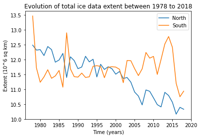

```python
df = pd.read_csv('seaice.csv') # Open the file where we will take the data
df.columns = df.columns.str.strip() # Remove spaces from columns
df = df.drop('Source Data', axis=1) # We are also going to remove this column, because it does not contribute much
# We have the data from 1978 to 2019
df_north = df[df['hemisphere'] == 'north']
df_south = df[df['hemisphere'] == 'south']

df_north_mean = df_north[df_north['Year'] <= 2018].groupby('Year')['Extent'].mean()
df_south_mean = df_south[df_south['Year'] <= 2018].groupby('Year')['Extent'].mean()

plt.plot(df_north_mean, label='North',)
plt.plot(df_south_mean, label='South')
plt.xlabel('Time (years)')
plt.ylabel('Extent (10^6 sq km)')
plt.title('Evolution of total ice data extent between 1978 to 2018')
plt.legend()
plt.show()
```

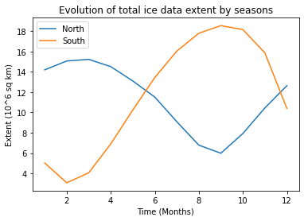

```python
df_north_mean = df_north[df_north['Year'] <= 2018].groupby('Month')['Extent'].mean()
df_south_mean = df_south[df_south['Year'] <= 2018].groupby('Month')['Extent'].mean()
plt.plot(df_north_mean, label='North')
plt.plot(df_south_mean, label='South')
plt.xlabel('Time (Months)')
plt.ylabel('Extent (10^6 sq km)')
plt.title('Evolution of total ice data extent by seasons')
plt.legend()
plt.show()
```

```python
df_north_max = df_north[df_north['Year'] <= 2018].groupby('Year')['Extent'].max()
df_north_min = df_north[df_north['Year'] <= 2018].groupby('Year')['Extent'].min()
df_north_max_min = pd.DataFrame({'Max': df_north_max, 'Min': df_north_min})
```

**North Hemisphere**

```python
df_north_max_min.head(41)
```

| Year | Max | Min |
| --- | --- | --- |
| 1978 | 14.585 | 10.231 |
| 1979 | 16.635 | 6.895 |
| 1980 | 16.302 | 7.533 |
| 1981 | 15.801 | 6.902 |
| 1982 | 16.325 | 7.160 |
| 1983 | 16.412 | 7.204 |
| 1984 | 15.809 | 6.396 |
| 1985 | 16.163 | 6.486 |
| 1986 | 16.158 | 7.122 |
| 1987 | 16.293 | 6.890 |
| 1988 | 16.309 | 7.048 |
| 1989 | 15.766 | 6.888 |
| 1990 | 16.249 | 6.011 |
| 1991 | 15.647 | 6.259 |
| 1992 | 15.576 | 7.159 |
| 1993 | 16.048 | 6.161 |
| 1994 | 15.770 | 6.934 |
| 1995 | 15.384 | 6.012 |
| 1996 | 15.484 | 7.147 |
| 1997 | 15.684 | 6.602 |
| 1998 | 16.070 | 6.293 |
| 1999 | 15.627 | 5.676 |
| 2000 | 15.498 | 5.943 |
| 2001 | 15.742 | 6.567 |
| 2002 | 15.624 | 5.625 |
| 2003 | 15.629 | 5.969 |
| 2004 | 15.300 | 5.770 |
| 2005 | 14.993 | 5.314 |
| 2006 | 14.777 | 5.746 |
| 2007 | 14.842 | 4.147 |
| 2008 | 15.354 | 4.548 |
| 2009 | 15.195 | 5.047 |
| 2010 | 15.351 | 4.590 |
| 2011 | 14.704 | 4.333 |
| 2012 | 15.307 | 3.340 |
| 2013 | 15.196 | 5.040 |
| 2014 | 15.007 | 4.988 |
| 2015 | 14.554 | 4.387 |
| 2016 | 14.566 | 4.145 |
| 2017 | 14.449 | 4.635 |
| 2018 | 14.504 | 4.553 |

**South hemisphere**

```python
df_south_max = df_south[df_south['Year'] <= 2018].groupby('Year')['Extent'].max()
df_south_min = df_south[df_south['Year'] <= 2018].groupby('Year')['Extent'].min()
df_south_max_min = pd.DataFrame({'Max': df_south_max, 'Min': df_south_min})

df_south_max_min.head(41)
```

| Year | Max | Min |
| --- | --- | --- |
| 1978 | 17.803 | 7.283 |
| 1979 | 18.361 | 2.911 |
| 1980 | 19.092 | 2.521 |
| 1981 | 18.856 | 2.694 |
| 1982 | 18.550 | 2.890 |
| 1983 | 18.811 | 2.843 |
| 1984 | 18.370 | 2.382 |
| 1985 | 18.931 | 2.602 |
| 1986 | 18.027 | 2.953 |
| 1987 | 18.524 | 3.010 |
| 1988 | 18.785 | 2.639 |
| 1989 | 18.274 | 2.723 |
| 1990 | 18.379 | 2.784 |
| 1991 | 18.671 | 2.554 |
| 1992 | 18.467 | 2.492 |
| 1993 | 18.710 | 2.281 |
| 1994 | 18.827 | 3.083 |
| 1995 | 18.762 | 3.330 |
| 1996 | 18.831 | 2.597 |
| 1997 | 18.792 | 2.264 |
| 1998 | 19.244 | 2.772 |
| 1999 | 18.981 | 2.707 |
| 2000 | 19.159 | 2.582 |
| 2001 | 18.494 | 3.441 |
| 2002 | 18.116 | 2.697 |
| 2003 | 18.680 | 3.626 |
| 2004 | 19.124 | 3.259 |
| 2005 | 19.295 | 2.804 |
| 2006 | 19.360 | 2.487 |
| 2007 | 19.086 | 2.723 |
| 2008 | 18.298 | 3.692 |
| 2009 | 19.299 | 2.671 |
| 2010 | 18.998 | 2.842 |
| 2011 | 18.954 | 2.319 |
| 2012 | 19.478 | 3.111 |
| 2013 | 19.608 | 3.679 |
| 2014 | 20.201 | 3.548 |
| 2015 | 18.912 | 3.544 |
| 2016 | 18.581 | 2.616 |
| 2017 | 18.145 | 2.080 |
| 2018 | 18.222 | 2.150 |

# 4. Discussion and Conclusion

**North**

We can observe that on the graph of *the total evolution of the extent of sea ice* between 1978 and 2018 a downward trend can clearly be observed throughout the time period. A critical point can also be observed from 2004 and 2007

In the second graph *evolution of total ice data extent by season* ice extent increases from autumn to March, where it begins to decrease until it reaches its minimum state in late summer

The historical **maximum** of ice extent has been: 16.635 *10^6 sq km* in 1979.

**South**

On the graph of *the total evolution of the extent of sea ice*, between 1978 and 2018 we can conclude that it has had periods of stability and some specific moments of great change. We can see that there have been three moments of ice loss (1980, 1988, 2017). The moments of ice gain have been two (1986, 2014). The rest of the time period has remained relatively stable (11.5 - 12 * 10^6 sq km)

In the second graph *evolution of total ice data extent by season* ice extent increases from February to September; then it starts to decrease.

# 5. Bibliography

## Daily Sea Ice Extent Data

### Dataset from:

https://www.kaggle.com/datasets/nsidcorg/daily-sea-ice-extent-data

(2019)